# Project Python Foundations: FoodHub Data Analysis

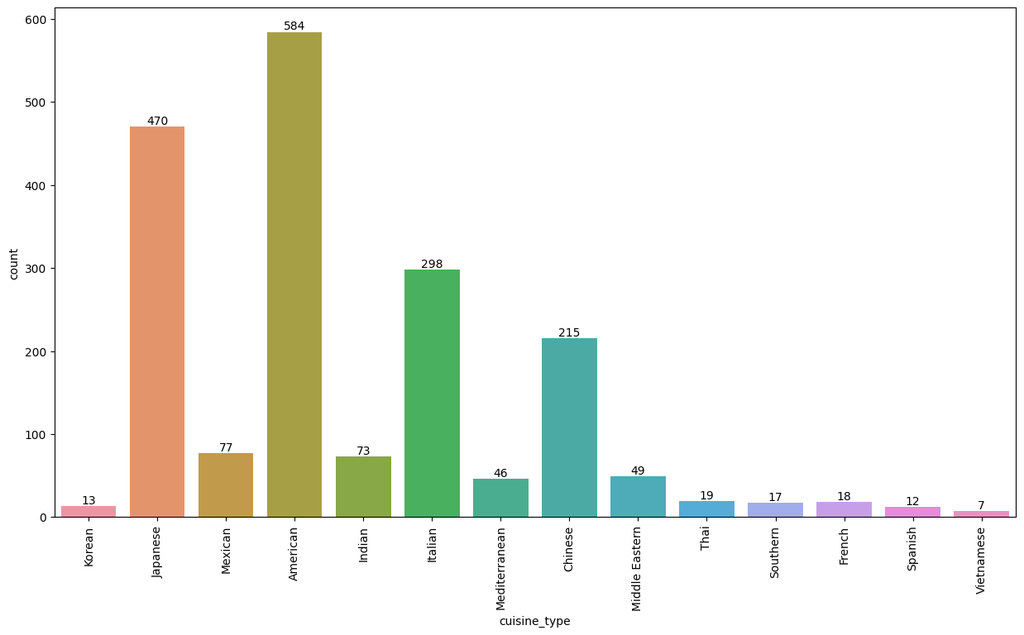

```python
plt.figure(figsize=(15,8))
ax=sns.countplot(data=df,x='cuisine_type')
plt.xticks(rotation=90)

for i in ax.containers:
    ax.bar_label(i,)
    plt.show()
```

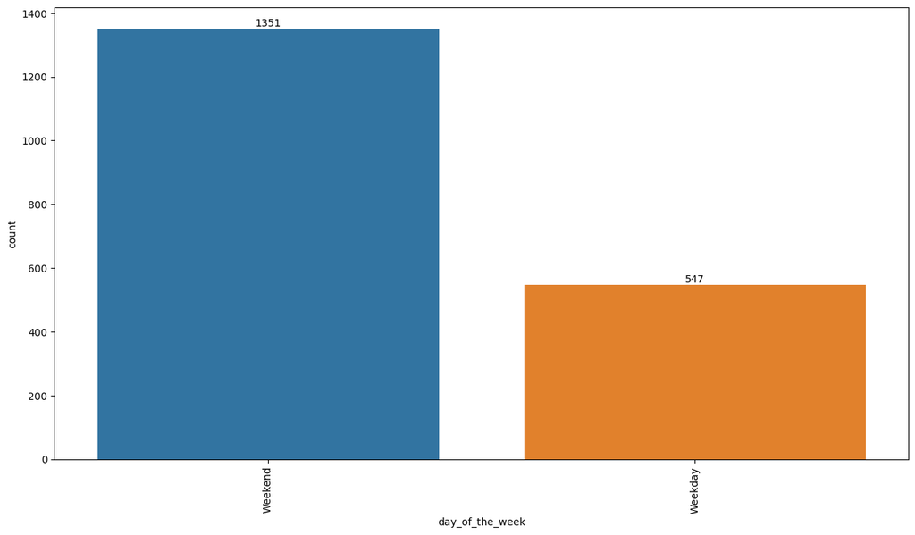

```python
plt.figure(figsize=(15,8))
ax=sns.countplot(data=df,x='day_of_the_week')
plt.xticks(rotation=90)

for i in ax.containers:
    ax.bar_label(i,)
    plt.show()
```

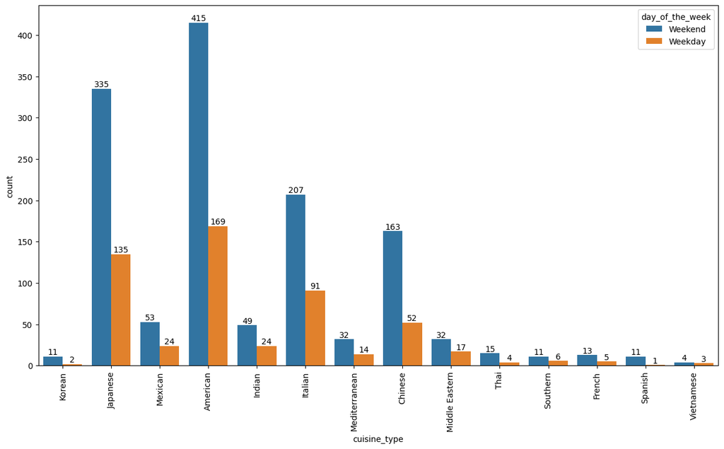

```python
plt.figure(figsize=(15,8))
ax = sns.countplot(data=df, x='cuisine_type',hue='day_of_the_week')
plt.xticks(rotation=90)
for i in ax.containers:
    ax.bar_label(i,)
```

```python
sns.lineplot
```

```
<function seaborn.relational.lineplot(data=None, *, x=None, y=None, hue=None, size=None, style=None, units=None, palette=None, hue_order=None, hue_norm=None, sizes=None, size_order=None, size_norm=None, dashes=True, markers=None, style_order=None, estimator='mean', errorbar=('ci', 95), n_boot=1000, …
```

#### Observations:

Minimum cost of the order is 5 and maximum cost of the order is 35 with a median of $14.1 Minumum rating is 3, max rating is 5, and median is 5 with average rating is 4.344 Minimum food preparation time is 20 minutes, max is 35 minutes, median is 31 minutes and average is 27.32 minutes Minimum delivery time is 15 minutes, max is 33 minutes, median is 25 minutes with average is 24.2 minutes American and Japanese has the most orders. Next to that Italian and chinese has the most orders. Order are more by 146% over the weekend.

```python
df_rating_null.info()
```

```
<class 'pandas.core.frame.DataFrame'>
RangeIndex: 1898 entries, 0 to 1897
Data columns (total 9 columns):
 #   Column                 Non-Null Count  Dtype
---  ------                 --------------  -----
 0   order_id               1898 non-null   object
 1   customer_id            1898 non-null   object
 2   restaurant_name        1898 non-null   object
 3   cuisine_type           1898 non-null   object
 4   cost_of_the_order      1898 non-null   float64
 5   day_of_the_week        1898 non-null   object
 6   rating                 1898 non-null   float64
 7   food_preparation_time  1898 non-null   int64
 8   delivery_time          1898 non-null   int64
dtypes: float64(2), int64(2), object(5)
memory usage: 133.6+ KB
```

### **Question 7**: Which are the top 5 restaurants in terms of the number of orders received? [1 mark]

```python
# Write the code here
df.groupby(['restaurant_name'])['order_id'].count().sort_values(ascending=False)
```

```
restaurant_name
Shake Shack                  219
The Meatball Shop            132
Blue Ribbon Sushi            119
Blue Ribbon Fried Chicken     96
Parm                          68
                            ...
Klong                          1
Kambi Ramen House              1
Il Bambino                     1
Hunan Manor                    1
Lamarca Pasta                  1
Name: order_id, Length: 178, dtype: int64
```

#### Observations:

Top 5 restaurants are:

1. Shake Shack
2. The Meatball shop
3. Blue Ribbon Sushi
4. Blue Ribbon Fried Chicken
5. Parm

### **Question 8**: Which is the most popular cuisine on weekends? [1 mark]

```python
# Write the code here
df.groupby(['cuisine_type','day_of_the_week'])['order_id'].count()
```

```
cuisine_type    day_of_the_week
American        Weekday            169
                Weekend            415
Chinese         Weekday             52
                Weekend            163
French          Weekday              5
                Weekend             13
Indian          Weekday             24
                Weekend             49
Italian         Weekday             91
                Weekend            207
Japanese        Weekday            135
                Weekend            335
Korean          Weekday              2
                Weekend             11
Mediterranean   Weekday             14
                Weekend             32
Mexican         Weekday             24
                Weekend             53
Middle Eastern  Weekday             17
                Weekend             32
Southern        Weekday              6
                Weekend             11
Spanish         Weekday              1
                Weekend             11
Thai            Weekday              4
                Weekend             15
Vietnamese      Weekday              3
                Weekend              4
Name: order_id, dtype: int64
```

[output not shown]

#### Observations:

American is the most popular cuisine over the weekend

### **Question 9**: What percentage of the orders cost more than 20 dollars? [2 marks]

```python
# Write the code here

df[df['cost_of_the_order']>20].count()/df.count()
```

```
order_id                0.292
customer_id             0.292
restaurant_name         0.292
cuisine_type            0.292
cost_of_the_order       0.292
day_of_the_week         0.292
rating                  0.292
food_preparation_time   0.292
delivery_time           0.292
dtype: float64
```

[output not shown]

#### Observations:

29% (29.2%) percentage of orders are more than 20 dollars

### **Question 10**: What is the mean order delivery time? [1 mark]

```python
# Write the code here
df['delivery_time'].mean()
```

```
24.161749209694417
```

#### Observations:

Mean delivery time: 24.162 Minutes

### **Question 11:** The company has decided to give 20% discount vouchers to the top 3 most frequent customers. Find the IDs of these customers and the number of orders they placed. [1 mark]

```python
# Write the code here
df.groupby(['customer_id'])['order_id'].count().sort_values(ascending=False)
```

```
customer_id
52832     13
47440     10
83287      9
250494     8
65009      7
          ..
105903     1
105992     1
106006     1
106324     1
405334     1
Name: order_id, Length: 1200, dtype: int64
```

#### Observations:

Top 3 most frequent customer Id are 52832, 47440, 83287 They placed 13,10,and 9 orders respectively

### **Question 12**: Perform a multivariate analysis to explore relationships between the important variables in the dataset. (It is a good idea to explore relations between numerical variables as well as relations between numerical and categorical variables) [10 marks]

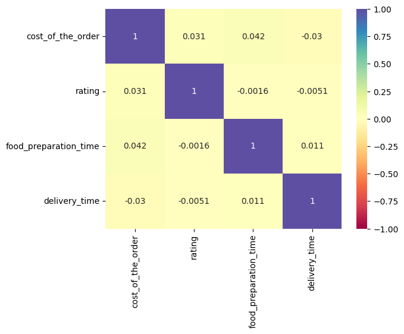

```python
# Write the code here

sns.heatmap(df.corr(), annot=True,cmap='Spectral',vmin=-1,vmax=1)
plt.show()
```

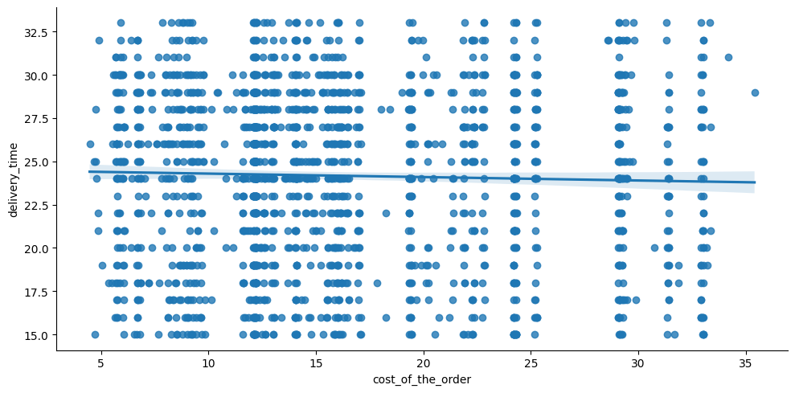

```python
plt.figure(figsize=(10,5))
sns.lmplot(data=df, x='cost_of_the_order',y='delivery_time',height=5,aspect=2)
plt.show()
```

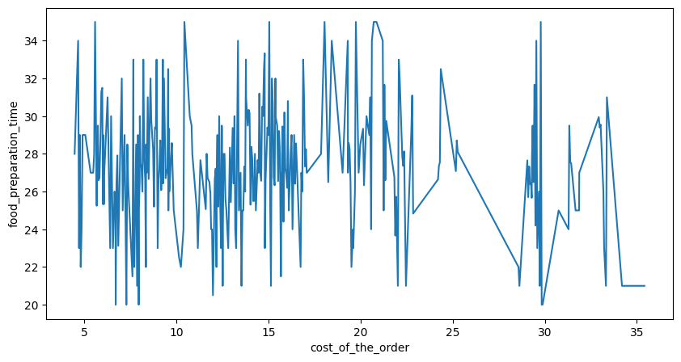

```python
plt.figure(figsize=(10,5))
sns.lineplot(data=df, x='cost_of_the_order',y='food_preparation_time',errorbar=None)
plt.show()
```

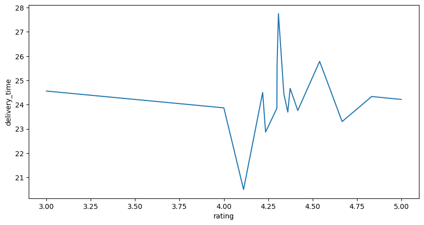

```python
plt.figure(figsize=(10,5))
sns.lineplot(data=df, x='rating',y='delivery_time',errorbar=None)
plt.show()
```

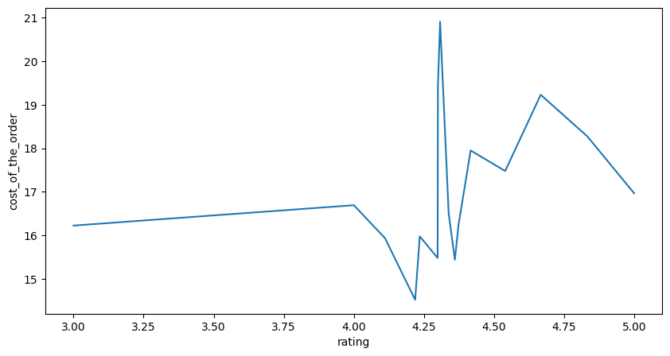

```python
plt.figure(figsize=(10,5))
sns.lineplot(data=df, x='rating',y='cost_of_the_order',errorbar=None)
plt.show()
```

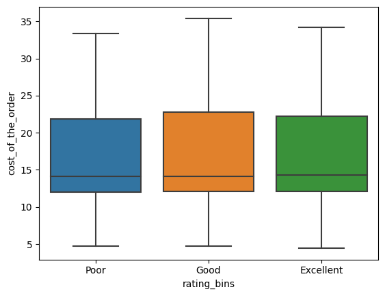

```python
# Write the code here
df['rating_bins']=pd.cut(df['rating'],bins=[0,3,4,5],labels=['Poor','Good','Excellent'])
sns.boxplot(data=df,x='rating_bins',y='cost_of_the_order')



plt.show()
```

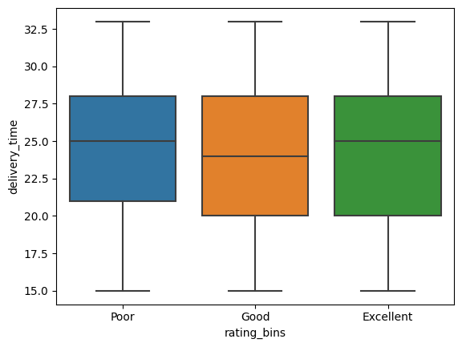

```python
# Write the code here
df['rating_bins']=pd.cut(df['rating'],bins=[0,3,4,5],labels=['Poor','Good','Excellent'])
sns.boxplot(data=df,x='rating_bins',y='delivery_time')
plt.show()
```

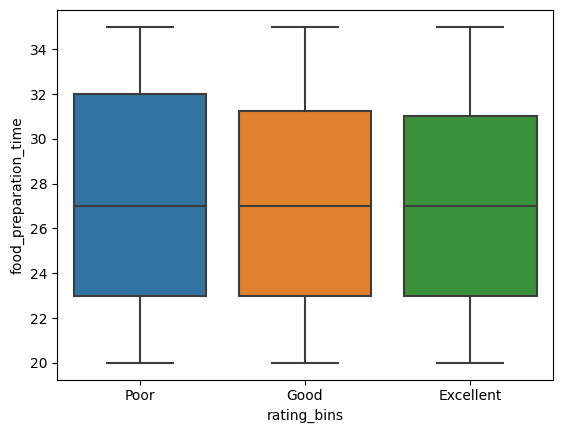

```python
# Write the code here
df['rating_bins']=pd.cut(df['rating'],bins=[0,3,4,5],labels=['Poor','Good','Excellent'])
sns.boxplot(data=df,x='rating_bins',y='food_preparation_time')
plt.show()
```

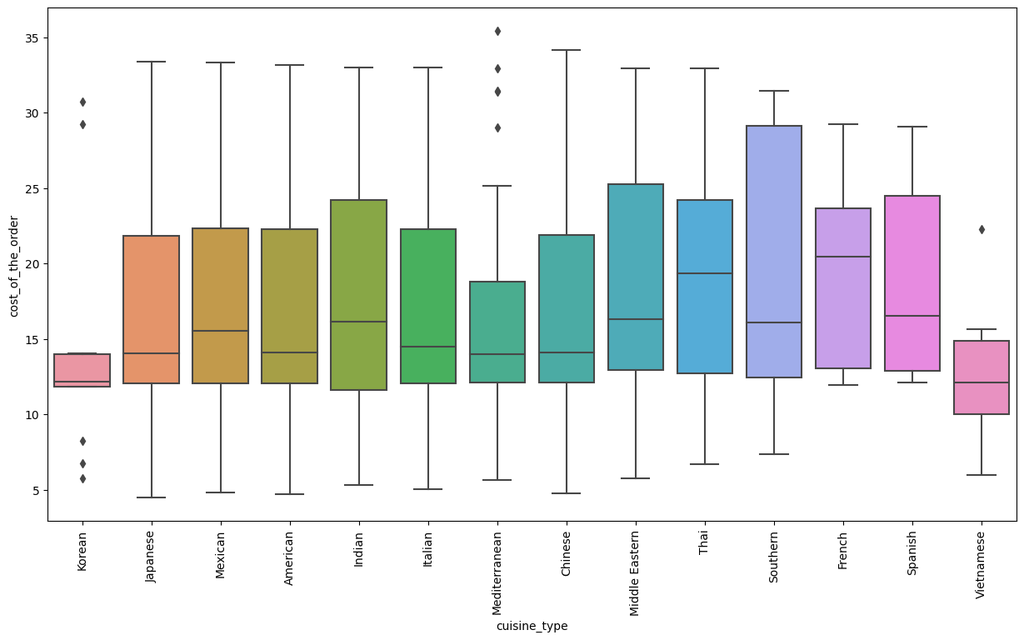

```python
plt.figure(figsize=(15,8))
sns.boxplot(data=df,x='cuisine_type',y='cost_of_the_order')
plt.xticks(rotation=90)
plt.show()
```

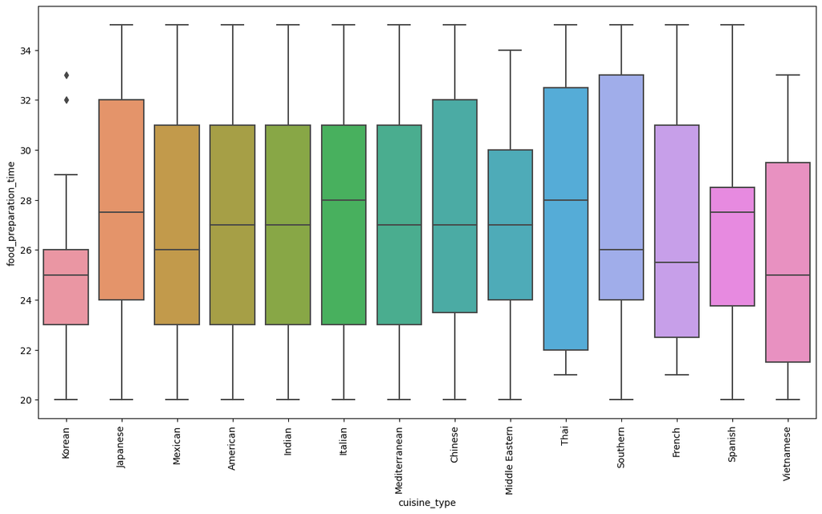

```python
plt.figure(figsize=(15,8))
sns.boxplot(data=df,x='cuisine_type',y='food_preparation_time')
plt.xticks(rotation=90)
plt.show()
```

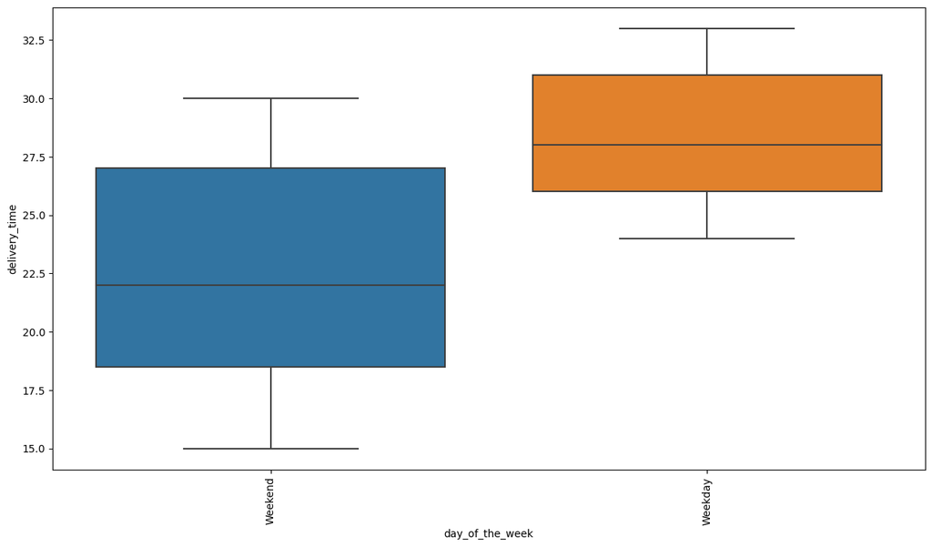

```python
plt.figure(figsize=(15,8))
sns.boxplot(data=df,x='day_of_the_week',y='delivery_time')
plt.xticks(rotation=90)
plt.show()
```

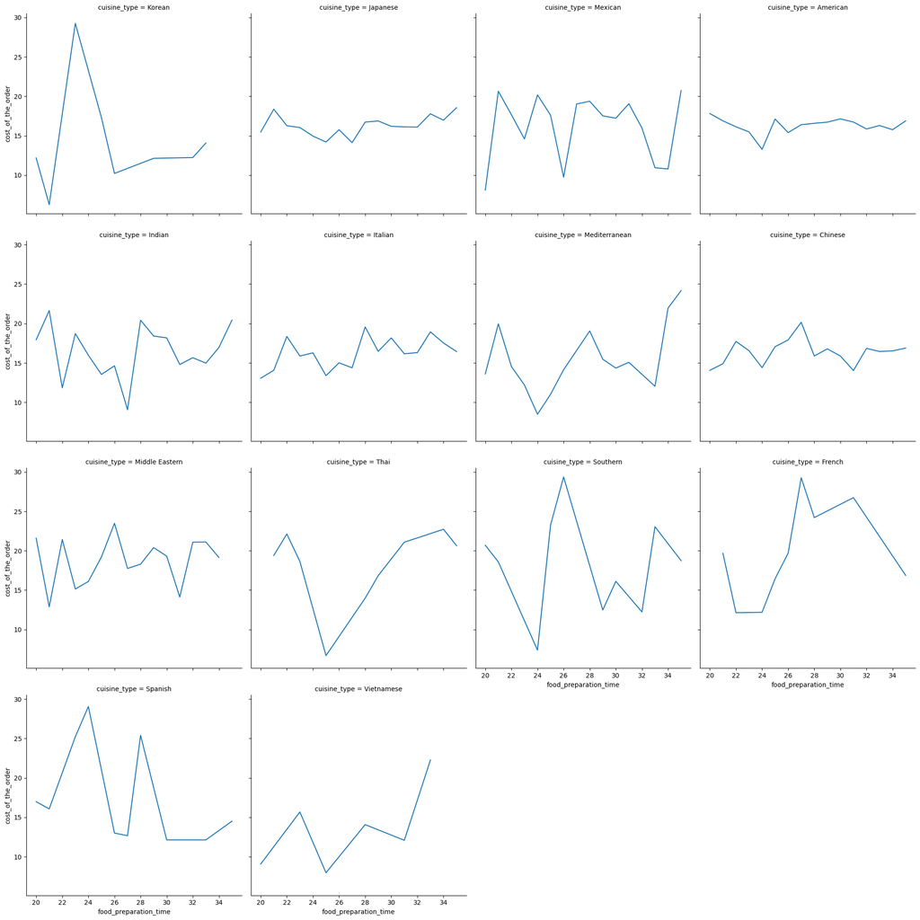

```python
sns.relplot(data=df,x='food_preparation_time',y='cost_of_the_order',col='cuisine_type',kind='line', errorbar=None, col_wrap=4)
plt.show()
```

#### Observations:

From the heatmap, numbers there is not much correlation or very weak correlation betwen the different variables. So, these vairables looks like does not influense the other variables and act alone.

#### Observation

There is no much corelation between delivery time and cost of the order.

From the lineplot there is no much correltion between cost of the order and food preparation time

From the lineplot, there is no coordination between delivery time and rating.

From the box plot, there is not much coordination between rating and the following variables

```
cost of the order
delivery time
foor prepartion time
```

### **Question 13:** The company wants to provide a promotional offer in the advertisement of the restaurants. The condition to get the offer is that the restaurants must have a rating count of more than 50 and the average rating should be greater than 4. Find the restaurants fulfilling the criteria to get the promotional offer. [3 marks]

```python
df_r_null = pd.read_csv('/content/drive/MyDrive/Python Course/foodhub_order.csv')
df_r_null['rating']=df_r_null['rating'].replace(['Not given'],np.nan)

restaurant_ratings_count = df_r_null.groupby(['restaurant_name'])['rating'].count()
rest_name = restaurant_ratings_count[restaurant_ratings_count >50].reset_index()
rest_name.rename(columns={"rating":"Record count"},inplace=True)
av_ratings = df.groupby(['restaurant_name'])['rating'].mean()
av_ratings = av_ratings[av_ratings >4].reset_index()
av_ratings.rename(columns={'rating':'Ave_Rating'},inplace=True)

outer_merged = pd.merge(rest_name, av_ratings, how="inner", on=["restaurant_name"])
outer_merged
```

|  | restaurant_name | Record count | Ave_Rating |
| --- | --- | --- | --- |
| 0 | Blue Ribbon Fried Chicken | 64 | 4.318 |
| 1 | Blue Ribbon Sushi | 73 | 4.279 |
| 2 | Shake Shack | 133 | 4.286 |
| 3 | The Meatball Shop | 84 | 4.454 |

### **Question 14:** The company charges the restaurant 25% on the orders having cost greater than 20 dollars and 15% on the orders having cost greater than 5 dollars. Find the net revenue generated by the company across all orders. [3 marks]

```python
# Write the code here
df_new_20=df[df['cost_of_the_order']>20]
df_new_5=df[(df['cost_of_the_order']<20) & (df['cost_of_the_order']>5)]

df_new_20['cost_of_the_order'].sum() * 25/100 + df_new_5['cost_of_the_order'].sum() * 15/100
```

```
6166.303
```

#### Observations:

Net revenue generated by all orders are 6166

### **Question 15:** The company wants to analyze the total time required to deliver the food. What percentage of orders take more than 60 minutes to get delivered from the time the order is placed? (The food has to be prepared and then delivered.) [2 marks]

```python
# Write the code here
df[((df['food_preparation_time']+df['delivery_time'])>60)].count()/df['order_id'].count() * 100
df_new = df[((df['food_preparation_time']+df['delivery_time'])>60)]
df_new['order_id'].count()/df['order_id'].count() * 100
```

```
10.537407797681771
```

#### Observations:

10.53% of orders took more than 60 minutes from the time place.

### **Question 16:** The company wants to analyze the delivery time of the orders on weekdays and weekends. How does the mean delivery time vary during weekdays and weekends? [2 marks]

```python
# Write the code here
df.groupby(['day_of_the_week'])['delivery_time'].mean()
```

```
day_of_the_week
Weekday   28.340
Weekend   22.470
Name: delivery_time, dtype: float64
```